# Solutions to Exercises of Week 4

*These exercises will not be graded. Solutions will be made available, but it is strongly advised that you try on your own first.*

*Make sure that any function you write has a docstring, and comments where appropriate.*

## Question 1

In this exercise you will download returns on 49 industry portfolios and create sorted portfolios from them to analyze if there is an anomaly or mispricing. The exercises will ask you to form $P=7$ portfolios sorted on momentum, and compute abnormal returns based on the Fama-Frech three factor model.

Feel free to explore other options and see how they impact the results! In particular, you can consider the following choices:

- *Characteristic*: e.g. size, value, momentum or reversal.
- *Number of sorts*: recommended to start with univariate sort.
- *Number of portfolios $P$*.
- *Value weighted or equal weighted portfolio returns*.
- *Asset pricing model*: consider for example CAPM or Fama-French three factor model (FF3)

**1.1.** Import the relevant modules:

```python
import numpy as np
import pandas as pd
import pandas_datareader.data as web
import statsmodels.api as sm
%matplotlib inline
import matplotlib.pyplot as plt
```

Download the data set `'49_industry_portfolios'` from source `'famafrench'` via `pandas-datareader`. The output of DataReader will be a `dict` object ([documentation](https://docs.python.org/3/library/stdtypes.html?highlight=dict#dict)). Use `dict['DESCR']` to see the data description. Index into the `dict` object to select the monthly value weighted returns and store it in a new DataFrame: use `dict[key]`, where `key` will be the index number as given in the data description.

*Note:* The column headers are all strings of length 5. An additional space is added if the industry name has less than 5 letters, e.g. 'Food ' instead of 'Food'. The spaces can be removed using the following code: `R.columns = [x.strip(' ') for x in R.columns]`, assuming that your DataFrame is called `R`. The function `strip(' ')` removes any leading and trailing spaces. It is not necessary to do this for the exercise, but avoids unexpected behavior when trying to select a column.

```python
startdate = pd.datetime(2010,1,1)
enddate = pd.datetime(2021,9,30)
#enddate = pd.datetime(2020,12,30)
ds = web.DataReader('49_industry_portfolios', 'famafrench', start=startdate, end=enddate)
print(ds['DESCR'])
```

```
49 industry portfolios
----------------------

This file was created by CMPT_IND_RETS using the 202109 CRSP database. It contains value- and equal-weighted returns for 49 industry portfolios. The portfolios are constructed at the end of June. The annual returns are from January to December. Missing data are indicated by -99.99 or -999. Copyright…

  0 : Average Value Weighted Returns -- Monthly (141 rows x 49 cols)
  1 : Average Equal Weighted Returns -- Monthly (141 rows x 49 cols)
  2 : Average Value Weighted Returns -- Annual (11 rows x 49 cols)
  3 : Average Equal Weighted Returns -- Annual (11 rows x 49 cols)
  4 : Number of Firms in Portfolios (141 rows x 49 cols)
  5 : Average Firm Size (141 rows x 49 cols)
  6 : Sum of BE / Sum of ME (12 rows x 49 cols)
  7 : Value-Weighted Average of BE/ME (12 rows x 49 cols)
```

```python
R = ds[0]  # Average value weighted returns; monthly
R.columns = [x.strip(' ') for x in R.columns]  # Remove spaces in column names
R.tail()
```

| Date | Agric | Food | Soda | Beer | Smoke | Toys | Fun | Books | Hshld | Clths | ... | Boxes | Trans | Whlsl | Rtail | Meals | Banks | Insur | RlEst | Fin | Other |
| --- | --- | --- | --- | --- | --- | --- | --- | --- | --- | --- | --- | --- | --- | --- | --- | --- | --- | --- | --- | --- | --- |
| 2021-05 | -6.12 | 3.94 | 1.99 | 1.99 | 2.04 | 2.94 | -0.86 | 2.90 | 0.29 | -0.57 | ... | -3.53 | 2.14 | 1.07 | -2.82 | -1.25 | 2.73 | 2.91 | 1.28 | 4.55 | 4.88 |
| 2021-06 | -2.35 | -3.06 | -1.45 | -0.98 | 1.99 | 12.01 | 1.56 | -0.23 | -0.26 | 8.82 | ... | -3.59 | -4.29 | -1.82 | 3.73 | -0.77 | -2.90 | -3.38 | -0.99 | 1.63 | -3.66 |
| 2021-07 | -3.06 | -2.29 | 4.53 | 1.09 | 0.96 | -3.07 | -7.45 | -2.55 | 3.91 | 4.54 | ... | -1.42 | -4.90 | 2.38 | -0.79 | 4.50 | -0.25 | 0.11 | 4.26 | 1.71 | -0.12 |
| 2021-08 | 2.62 | -0.48 | -0.09 | -1.67 | 3.47 | -9.69 | 10.28 | 0.47 | 0.03 | -0.63 | ... | 9.96 | -0.36 | 1.45 | 2.99 | -0.52 | 1.73 | 1.90 | 2.96 | 6.10 | 2.23 |
| 2021-09 | -4.14 | -2.21 | -5.95 | -2.97 | -7.05 | -7.82 | 2.17 | 1.27 | -4.18 | -9.11 | ... | -6.71 | -3.72 | -4.90 | -4.27 | -0.14 | 0.85 | -3.77 | -1.09 | -5.64 | -4.78 |

5 rows × 49 columns

**1.3.** We will need size information to compute value weighted portfolio returns. We will calculate size per industry as the product of the average firm size in the industry times the number of firms in the industry. Both, average size and number of firms dataframes, are available in the same `dict` object as the returns. Also store size in a new DataFrame.

```python
size = ds[5] * ds[4]  # Average size times number of firms
size.columns = [x.strip(' ') for x in size.columns]  # Remove spaces in column names
size.tail()
```

| Date | Agric | Food | Soda | Beer | Smoke | Toys | Fun | Books | Hshld | Clths | ... | Boxes | Trans | Whlsl | Rtail | Meals | Banks | Insur | RlEst | Fin | Other |
| --- | --- | --- | --- | --- | --- | --- | --- | --- | --- | --- | --- | --- | --- | --- | --- | --- | --- | --- | --- | --- | --- |
| 2021-05 | 41283.13 | 537493.55 | 294628.08 | 309774.56 | 237489.51 | 132472.32 | 420113.46 | 34460.92 | 715054.86 | 402333.60 | ... | 95724.72 | 986287.94 | 431808.50 | 3862872.81 | 625774.18 | 3438452.16 | 1456624.59 | 82568.64 | 1081476.12 | 1628052.00 |
| 2021-06 | 38660.93 | 557275.70 | 300499.44 | 315787.68 | 242326.62 | 136308.48 | 416492.70 | 35433.71 | 716679.99 | 399495.90 | ... | 92148.57 | 1005147.72 | 435925.56 | 3751094.10 | 616126.06 | 3521215.68 | 1496860.24 | 83627.52 | 1129002.48 | 1706605.68 |
| 2021-07 | 37366.42 | 539679.82 | 295144.40 | 312286.05 | 243836.52 | 167006.61 | 477642.71 | 36382.22 | 670498.42 | 394007.21 | ... | 91302.80 | 993610.24 | 433794.27 | 4004748.38 | 704372.22 | 3454442.48 | 1464882.00 | 93322.68 | 1229562.90 | 1685662.11 |
| 2021-08 | 36222.48 | 526671.94 | 308522.00 | 315685.71 | 246170.52 | 161782.65 | 442027.32 | 35422.66 | 694002.90 | 411855.15 | ... | 90009.00 | 944955.52 | 443452.10 | 3971365.59 | 735915.78 | 3439193.04 | 1465101.00 | 97299.51 | 1248516.72 | 1683366.57 |
| 2021-09 | 37066.68 | 522574.72 | 308231.12 | 310192.38 | 254710.02 | 146030.31 | 487473.42 | 35558.04 | 693880.72 | 408802.58 | ... | 98739.70 | 939379.20 | 447361.20 | 4087020.99 | 730113.69 | 3492860.18 | 1490908.32 | 100173.48 | 1322629.68 | 1720096.62 |

5 rows × 49 columns

**1.4.** Before sorting and grouping the assets into portfolios, we need to compute or read the characteristic(s). Momentum is defined as the return from month $t-12$ to $t-2$.

```python
r = np.log(1 + R / 100) * 100  # Transform to log returns, such that we can aggregate over time
mom = r.shift(2).rolling(11).sum()  # Computes the sum over the period t-12 to t-2.
mom = mom[12:]
mom.head()
```

| Date | Agric | Food | Soda | Beer | Smoke | Toys | Fun | Books | Hshld | Clths | ... | Boxes | Trans | Whlsl | Rtail | Meals | Banks | Insur | RlEst | Fin | Other |
| --- | --- | --- | --- | --- | --- | --- | --- | --- | --- | --- | --- | --- | --- | --- | --- | --- | --- | --- | --- | --- | --- |
| 2011-01 | -31.220916 | 10.429271 | 33.694828 | 11.794906 | 20.350070 | 27.659925 | 57.089026 | 0.994122 | 6.050642 | 30.658578 | ... | 10.852913 | 22.772845 | 12.415982 | 12.085923 | 32.298964 | -4.737564 | 10.589992 | 10.492334 | -3.597947 | 7.418043 |
| 2011-02 | -9.654855 | 14.299716 | 37.050475 | 19.072846 | 27.900449 | 31.938492 | 53.655340 | 5.608365 | 10.775626 | 34.892175 | ... | 25.470463 | 30.047318 | 21.615278 | 17.464737 | 33.253889 | 6.028143 | 18.126136 | 21.554841 | 13.670333 | 16.270274 |
| 2011-03 | 2.061569 | 9.153055 | 26.054067 | 15.136010 | 20.220431 | 11.424116 | 54.274717 | 11.426113 | 6.157143 | 25.622905 | ... | 21.509830 | 22.546826 | 18.682910 | 11.947183 | 26.263020 | 6.752217 | 16.745060 | 16.768142 | 11.312468 | 22.447326 |
| 2011-04 | -1.165160 | 11.321598 | 21.322816 | 9.803607 | 22.576549 | 11.057488 | 42.012963 | 8.628257 | 5.735140 | 23.343785 | ... | 19.740546 | 16.149074 | 15.773057 | 7.358869 | 21.946074 | 0.148875 | 13.153773 | 12.631112 | 7.453193 | 16.924680 |
| 2011-05 | 9.889416 | 12.768457 | 27.546170 | 14.874389 | 31.256315 | 13.539055 | 26.730713 | 6.134313 | 4.752062 | 14.701067 | ... | 18.396121 | 15.394792 | 14.033373 | 6.004625 | 16.579189 | -4.651569 | 14.306116 | 8.384210 | 6.728663 | 10.900137 |

5 rows × 49 columns

**1.5.** Now that we have a characteristic, we can form the sorted portfolios. Create $P=7$ portfolios sorted on your momentum. Compute the portfolio returns and store them in a new DataFrame `R_portf`.

*Note*: If you have portfolios sorted on momentum or reversal, these are resorted and grouped each month. If you have portfolios based on accouting numbers, these are resorted annually.

Below is the implementation in the form of a function.

```python
def portsort(R, X, P, size, w='vw'):
    '''Computes P portfolio returns sorted on one characteristic X, with monthly rebalancing.'''

    # Preliminaries
    R_portf = pd.DataFrame(columns=range(1,P+1), index=R.index, dtype='float')   # Empty DataFrame, but columns of group numbers and index of r, and float dtype
    q = np.linspace(0,1,P+1)  # quantile breakpoints on [0,1] interval

    # For each month
    for t in R.index:
        X_t = X.loc[t]  # Define for convenience

        # Find bounds/breakpoints as quantiles and convert to array (remove index)
        brkpts = X_t.quantile(q).values
        brkpts[0] = -np.Inf   # First lower bound

        for p in range(1,P+1):  # Note: df[p] will index to portfolio p in DataFrame with integer column headers, but list[p] to the element indexed by p in a list/array.
            # Select assets and time period
            R_smpl = R.loc[t, (brkpts[p-1] < X_t) & (X_t <= brkpts[p])]

            if w == 'vw':
                # Compute the value weighted return
                size_smpl = size.loc[t, (brkpts[p-1] < X_t) & (X_t <= brkpts[p])]  # Select size
                R_portf.loc[t, p] = R_smpl@size_smpl / size_smpl.sum()  # Sum-product with relative size
            elif w == 'ew':
                R_portf.loc[t, p] = R_smpl.mean()  # Equal weighted return
            else:
                raise ValueError('Only equally weighted ("ew") and value weigthed ("vw") supported.')

    return R_portf#.astype('float')  # Ensure that contents are floats
```

```python
P = 7
R_portf = portsort(R[12:], mom, P, size = size[12:], w = 'vw')
R_portf.head()
```

| Date | 1 | 2 | 3 | 4 | 5 | 6 | 7 |
| --- | --- | --- | --- | --- | --- | --- | --- |
| 2011-01 | 2.503475 | 0.888080 | 5.456729 | 0.981223 | 1.379534 | 0.825585 | -1.459662 |
| 2011-02 | 2.416608 | 3.280501 | 2.273089 | 5.090044 | 6.001589 | 5.017211 | 1.616869 |
| 2011-03 | 0.271533 | 0.165122 | 0.989066 | -0.401490 | -0.243936 | 2.204285 | 2.321001 |
| 2011-04 | 3.161940 | 3.789710 | 2.856440 | 2.813568 | 3.868618 | 3.073146 | 2.187173 |
| 2011-05 | -0.805504 | -0.062957 | 0.045946 | -0.898256 | -1.567418 | -0.559137 | -3.948730 |

**1.6.** Compute the average return over time for each portfolio. Is there a pattern?

```python
R_portf.mean()
```

```
1    0.926375
2    1.192080
3    1.064262
4    1.155653
5    1.172547
6    1.163632
7    1.156783
dtype: float64
```

Portfolios with higher momentum have on average higher returns over the sample period. This is particularly strong when comparing portfolio 1 with portfolio 6 and 7. Momentum is a characteristic that distinguishes between assets in terms of returns. Portfolio 2 is a bit of an outlier though.

**1.7.** Now that we have our portfolios, we can set up the factor model. The monthly factors of the Fama-French three factor model (FF3) can be obtained from [Kenneth French's website](http://mba.tuck.dartmouth.edu/pages/faculty/ken.french/data_library.html).

Download the data set `'F-F_Research_Data_Factors'` from source `'famafrench'` via `pandas-datareader`. The output of DataReader is again a `dict` object.

```python
ds2 = web.DataReader('F-F_Research_Data_Factors','famafrench',start=startdate,end=enddate)
print(ds2['DESCR'])
```

```
F-F Research Data Factors
-------------------------

This file was created by CMPT_ME_BEME_RETS using the 202109 CRSP database. The 1-month TBill return is from Ibbotson and Associates, Inc. Copyright 2021 Kenneth R. French

  0 : (141 rows x 4 cols)
  1 : Annual Factors: January-December (11 rows x 4 cols)
```

```python
ff3factors = ds2[0]
ff3factors = ff3factors[12:]
ff3factors.tail()
```

| Date | Mkt-RF | SMB | HML | RF |
| --- | --- | --- | --- | --- |
| 2021-05 | 0.29 | -0.28 | 7.04 | 0.0 |
| 2021-06 | 2.75 | 1.80 | -7.76 | 0.0 |
| 2021-07 | 1.27 | -3.96 | -1.75 | 0.0 |
| 2021-08 | 2.90 | -0.48 | -0.13 | 0.0 |
| 2021-09 | -4.37 | 0.80 | 5.09 | 0.0 |

**1.8.** Obtain the portfolios' excess returns by deducting the risk-free rate ('RF' in the DataFrame of the FF3 factors) from the portfolios returns.

```python
R_portf = R_portf.subtract(ff3factors.RF, axis=0)
R_portf.dropna(inplace=True)
R_portf.tail()
```

| Date | 1 | 2 | 3 | 4 | 5 | 6 | 7 |
| --- | --- | --- | --- | --- | --- | --- | --- |
| 2021-05 | 1.191212 | 0.291773 | 0.133289 | 0.597934 | -0.051408 | 1.494261 | -2.195294 |
| 2021-06 | 1.504090 | 0.908289 | 2.604111 | 4.358357 | 2.483081 | -2.479343 | 2.917839 |
| 2021-07 | 1.945222 | 1.991785 | 3.122408 | -0.767809 | 0.329229 | -1.555959 | 0.460804 |
| 2021-08 | 2.131776 | 2.844311 | 3.349363 | 4.170653 | 1.140266 | 1.944366 | 0.985770 |
| 2021-09 | -3.533483 | -5.821606 | -5.510080 | -4.898795 | -0.606878 | -3.055270 | -7.371527 |

**1.9.** Estimate the $\alpha_p$ and $\beta_p$ by using the following $P$ time series regressions:

$$ R_{pt}-R_{f,t} = \alpha_p + \beta_p' f_t + \varepsilon_{pt}, $$

where $\varepsilon_{pt} \sim N(0,\sigma^2_p)$, for $t = 1,\ldots,T$, $p = 1,\ldots,P$, where $f_t$ are your risk factors. In the case of the FF3 model, we have $f_t = (R_{mt}-R_{f,t},SMB_{t},HML_{t})'$.

Store the alpha estimates and $t$ statistics in a new DataFrame.

```python
ff3factors = sm.add_constant(ff3factors.drop(columns='RF'))  # Add a constant, and remove risk free rate
ff3factors.head()
```

| Date | const | Mkt-RF | SMB | HML |
| --- | --- | --- | --- | --- |
| 2011-01 | 1.0 | 1.99 | -2.44 | 0.77 |
| 2011-02 | 1.0 | 3.49 | 1.47 | 1.24 |
| 2011-03 | 1.0 | 0.46 | 2.56 | -1.88 |
| 2011-04 | 1.0 | 2.90 | -0.32 | -2.48 |
| 2011-05 | 1.0 | -1.27 | -0.65 | -2.00 |

```python
alpha = []
t_a = []
ff3ret = []  # Expected return
for p in range(1,P+1):
    ff3 = sm.OLS(R_portf[p], ff3factors)
    results = ff3.fit()
    alpha.append(results.params[0])
    t_a.append(results.tvalues[0])
    ff3ret.append(results.fittedvalues.mean() - results.params[0])
```

```python
R_abnorm = pd.DataFrame(index=range(1,P+1))
R_abnorm['alpha'] = alpha
R_abnorm['t'] = t_a
```

**1.10.** Inspect the alphas and $t$ statistics. Are there significant abnormal returns?

```python
R_abnorm
```

|  | alpha | t |
| --- | --- | --- |
| 1 | -0.316343 | -1.214719 |
| 2 | -0.017220 | -0.095835 |
| 3 | -0.068341 | -0.394198 |
| 4 | -0.006155 | -0.042912 |
| 5 | 0.030533 | 0.205836 |
| 6 | 0.012113 | 0.080507 |
| 7 | -0.193728 | -1.050035 |

There is little statistical power to reject the null of $\alpha_p = 0$ for any of the portfolios. At least in this sample it seems that the FF3 model explains the differences in average returns across portfolios.

**1.11.** Make a scatter plot of the average return against the expected return (as implied by the asset pricing model).

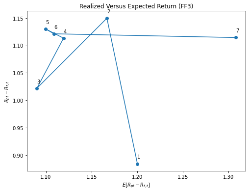

```python
plt.figure(figsize=(8,6))
plt.plot(ff3ret, R_portf.mean(), marker='o')
for i, p in enumerate(R_portf.columns):   # enumerate(x) returns iterable with each element a tuple: (index, x[index])
    xi = ff3ret[i]
    yi = R_portf[p].mean()
    plt.annotate(p, (xi, yi), xytext=(xi, yi+0.01))   # Label the portfolios
plt.xlabel('$E[R_{pt}-R_{f,t}]$')
plt.ylabel('$R_{pt}-R_{f,t}$')
plt.title('Realized Versus Expected Return (FF3)');
```